# BF Group Project

Harshal Utekar, Stephen Lee, Simran Dhawan

## Importing Libraries

```r
library(fpp)
library(fpp2)
library(TTR)
library(data.table)
```

## Importing the data

```r
library(readxl)
honda <- read_excel("Honda Sales Data.xlsx")
```

#### Data Type

```r
str(honda)
```

```
## tibble [200 x 3] (S3: tbl_df/tbl/data.frame)
##  $ Year     : num [1:200] 2005 2005 2005 2005 2005 ...
##  $ Month    : num [1:200] 1 2 3 4 5 6 7 8 9 10 ...
##  $ Car_Sales: num [1:200] 67840 81979 109949 116495 103486 ...
```

```r
class(honda)
```

```
## [1] "tbl_df"     "tbl"        "data.frame"
```

```r
honda_month <- month.abb[honda$Month]
```

## Converting into a Time-Series

```r
honda_ts <- ts(honda$Car_Sales,frequency = 12,start = c(2005,1),end = c(2021,8))
honda_ts
```

```
##         Jan    Feb    Mar    Apr    May    Jun    Jul    Aug    Sep    Oct
## 2005  67840  81979 109949 116495 103486 114672 123308 136952 104529  94497
## 2006  84413  92498 111282 119752 125639 111342 133601 132990  99903  94747
## 2007  87773  96368 126406 111226 129447 114159 126668 141906 112831 101913
## 2008  87343 102313 120446 122000 153104 130083 125914 131766  87629  75755
## 2009  63175  63916  79374  92216  88875  92140 106028 151814  69970  75751
## 2010  60347  71732  96540 102978 105407  95788  99420  97195  86639  87800
## 2011  68308  87263 121039 113195  81773  75184  71100  73267  79521  87218
## 2012  74628 197798 115833 109837 119411 109438 104119 115675 103475  94270
## 2013  84137  96623 121938 117100 125649 123150 126289 149378  93915 100242
## 2014  80808  88860 117738 118333 137928 117817 123428 151551 104391 105906
## 2015  90202  92474 111623 115194 137551 118870 131409 140178 119046 115572
## 2016  90247 106213 123369 132623 133547 127363 139125 135325 120842 113292
## 2017  97178 110822 125531 123984 134475 125755 136803 131076 129776 114655
## 2018  95634 104588 128585 113813 140250 132031 125355 132834 119157 108558
```

[output cut: 21 more lines]

```r
class(honda_ts)
```

```
## [1] "ts"
```

```r
attributes(honda_ts)
```

```
## $tsp
## [1] 2005.000 2021.583   12.000
##
## $class
## [1] "ts"
```

## Plot the time-series

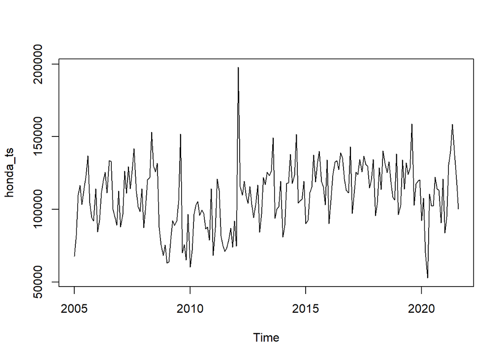

```r
plot(honda_ts)
```

Observations: 1. The period from 2005-2009 displayed a consistent level of seasonality in tandem with a modest upward trend. However, during 2009, year-over-year sales decreased precipitously largely due to the Global Financial Crisis, which negatively shocked demand for Honda cars. 2. By February 2012, the plot showed a dramatic increase in sales volume, which was primarily due to Honda’s launch of new car models. 3. However, after this period and after sales levels normalized, sales volumes returned to a seasonal pattern without an obvious upward or downward long term trend. 4. The 2020 COVID period led to a severe drop in sales, followed by an equally strong recovery. We believe U.S. federal government assistance in the form of cash injections into the economy in conjunction with rock bottom interest rates contributed significantly to the recovery. 5. However, sales volumes exhibited another meaningful decrease in 2021. We accord these developments, and the break from normal seasonality, to the shortages of chip manufacturing and overall global supply chain constraints.

#### Determining Central Tendency

```r
summary(honda_ts)
```

```
##    Min. 1st Qu.  Median    Mean 3rd Qu.    Max.
##   52705   94440  111483  109536  124327  197798
```

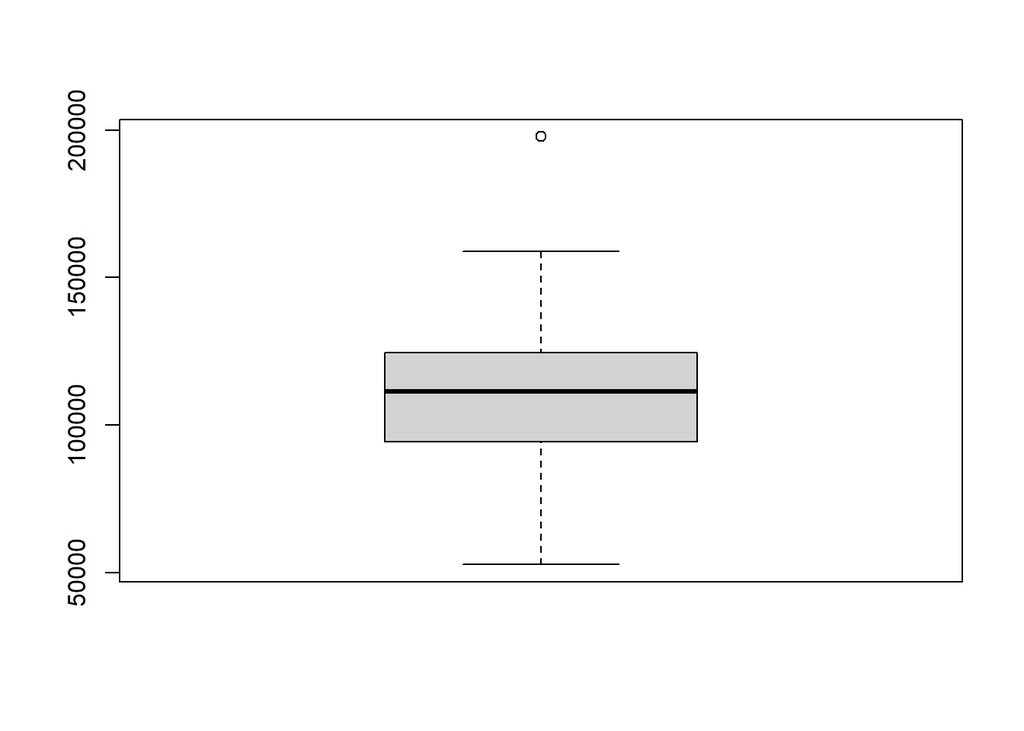

```r
boxplot(honda_ts)
```

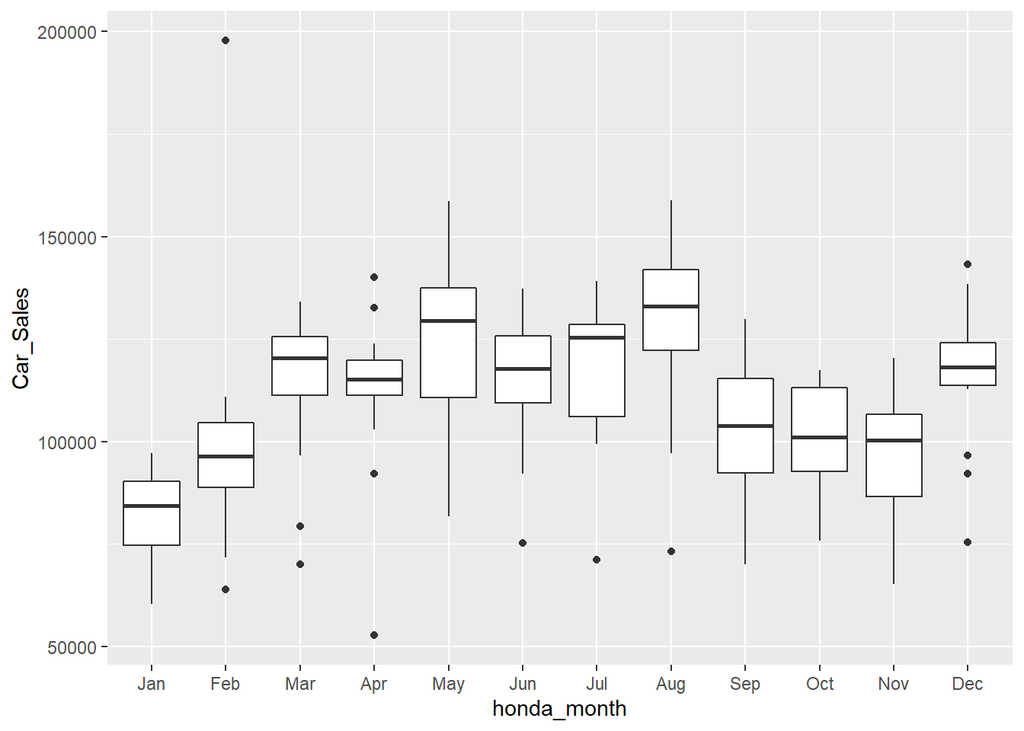

```r
ggplot(honda,aes(x=honda_month,y=Car_Sales))+geom_boxplot()+scale_x_discrete(limits = month.abb)
```

1. From the summary, we can see that on average sales have been around 110,000 units and have never dropped below the 50,000 mark. 2. The box plot exhibits average monthly sales. Historically, the seasonally slowest period has been January, while the seasonally strongest period has been May-August, with August being the highest sales month.

## Decomposition using STL

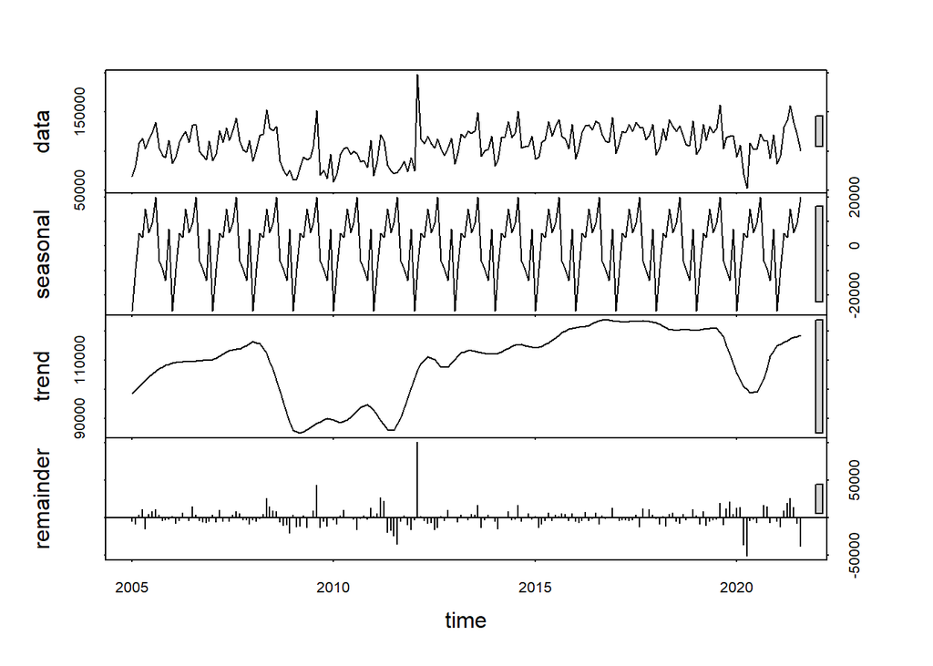

```r
honda_fit <- stl(honda_ts,s.window = "periodic")
plot(honda_fit)
```

## Decomposition using Decompose

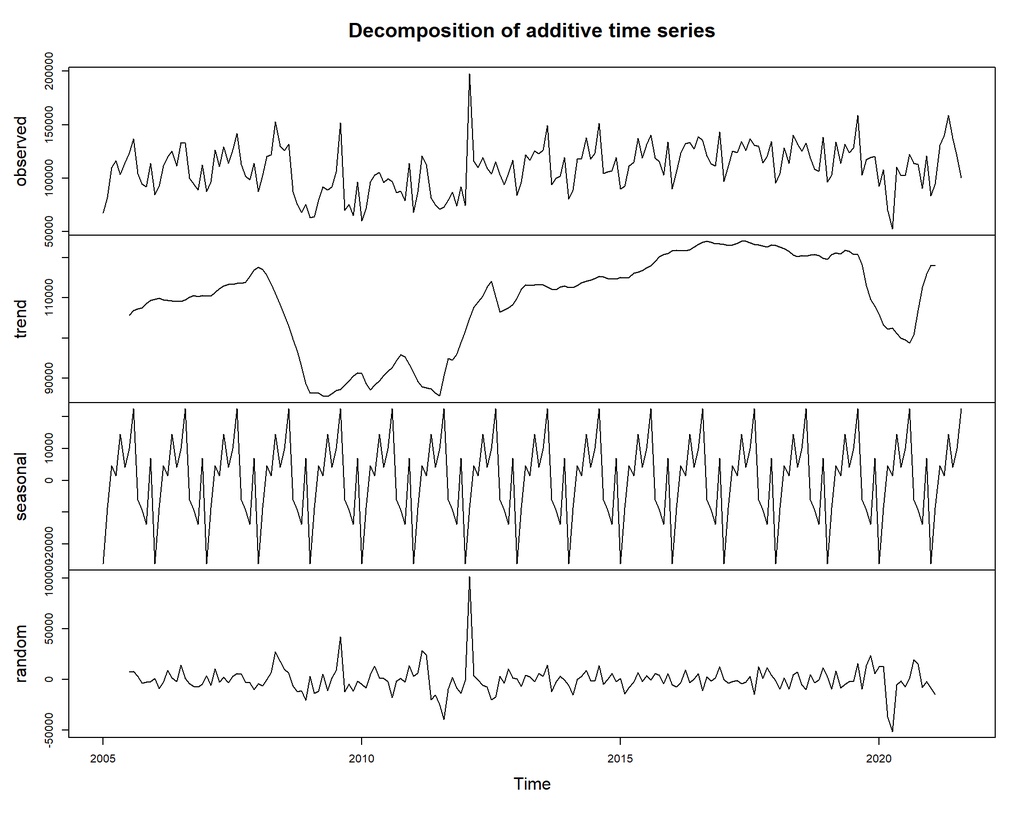

```r
honda_d_fit <- decompose(honda_ts)
plot(honda_d_fit)
```

1. As observed in the time-series plot, trend has historically contributed most to the observed data, followed by seasonality. 2. Barring major shocks like the Financial Crisis and COVID-19, the trend line has been steadily rising, suggesting that going forward as supply chains normalize, inventories become replenished, and interest rates return to historical averages, we could see a return to a low upward sloping trend line over the long term. 3. The randomness is relatively low in the data except for the 2012 spike and the COVID-related decrease in 2020. 4. The time-series is additive.

## Seasonally Adjust the Time-series:

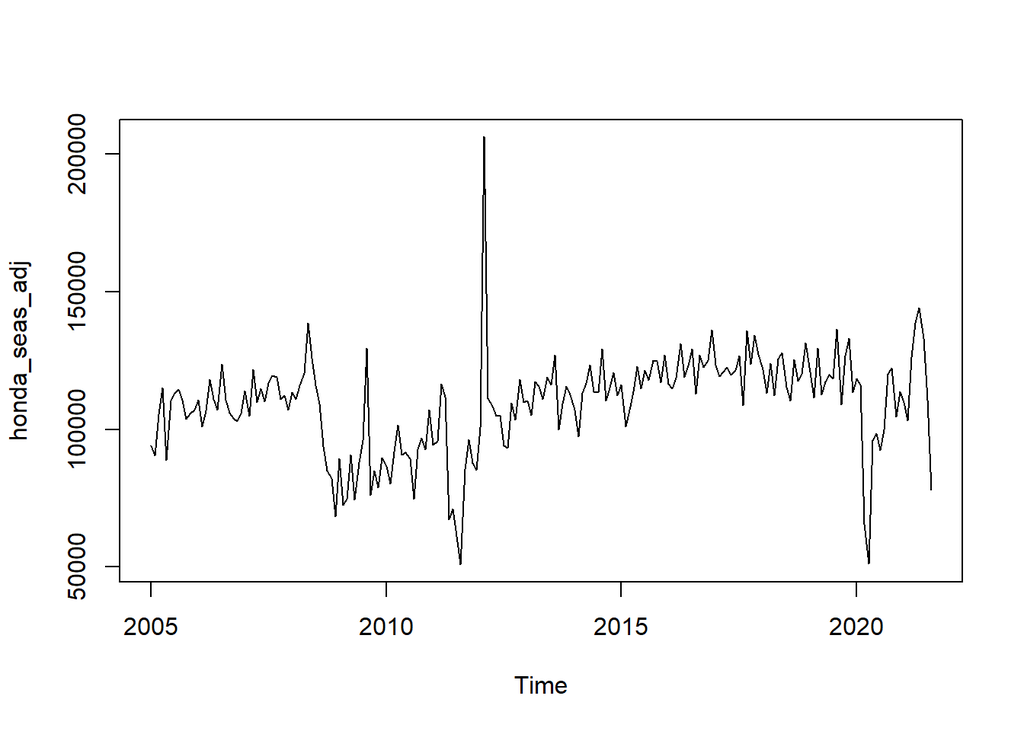

```r
honda_seas_adj <- seasadj(honda_d_fit)
plot(honda_seas_adj)
```

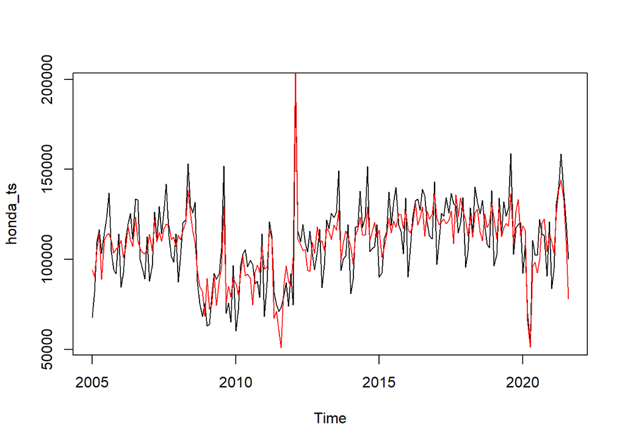

```r
plot(honda_ts)
lines(honda_seas_adj,col="Red")
```

When seasonally adjusting the time series we can see that the graph does not change much. The upward and downward spikes are still relatively the same; only the magnitude of seasonality has decreased. Since seasonality is a key factor in determining monthly sales volumes, we do not believe adjusting our model to eliminate or diminish seasonality would be wise.

#### Seasonal Indices:

```r
honda_d_fit$type
```

```
## [1] "additive"
```

```r
honda_d_fit$figure
```

```
##  [1] -26191.506  -8575.225   4527.050   1456.672  14517.080   4108.722
##  [7]   9969.872  22364.629  -6124.063  -9221.204 -13786.287   6954.260
```

```r
honda_s_indice <- round(honda_d_fit$figure/10000,2)
honda_s_indice
```

```
##  [1] -2.62 -0.86  0.45  0.15  1.45  0.41  1.00  2.24 -0.61 -0.92 -1.38  0.70
```

Highest: August Lowest: January

### Acf

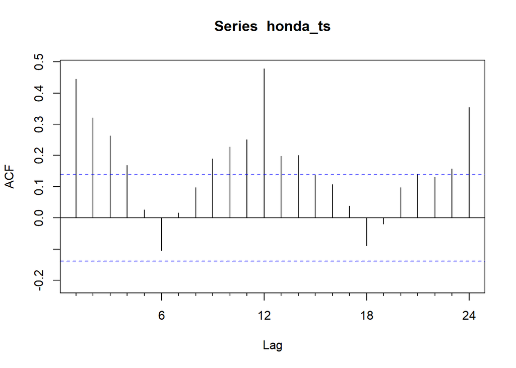

```r
honda_acf <- Acf(honda_ts,type="correlation")
```

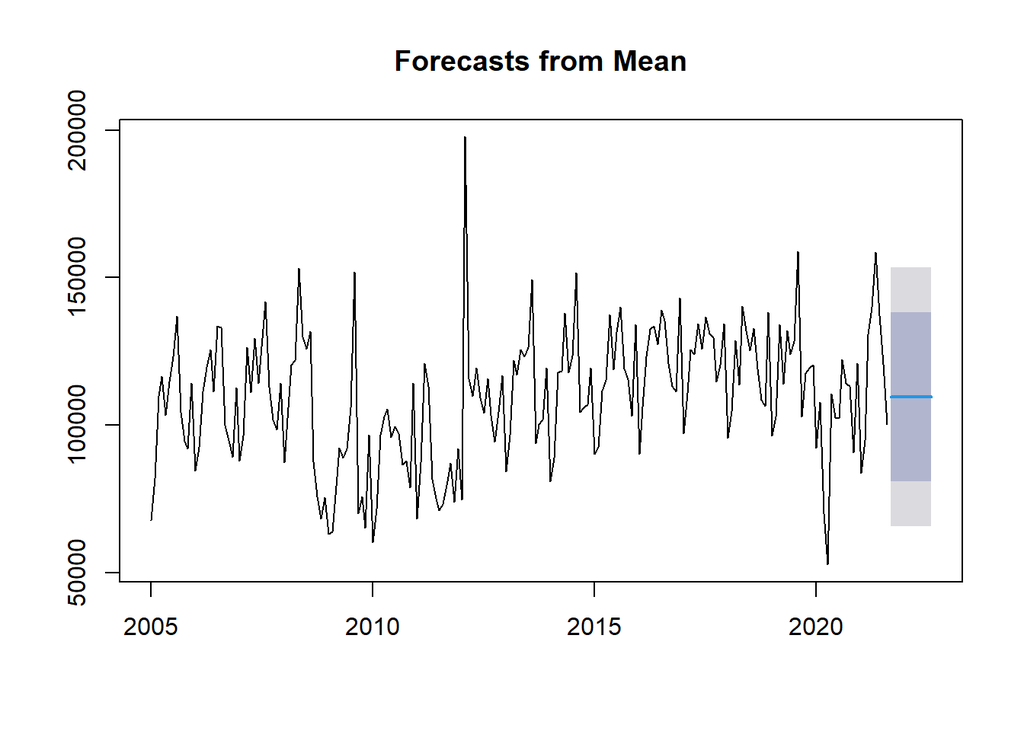

```r
honda_mean_f <- meanf(honda_ts,h=12)
plot(honda_mean_f)
```

#### Accuracy for the Mean Forecast:

```r
acc_mean <- accuracy(honda_mean_f)
```

## Naive Forecast

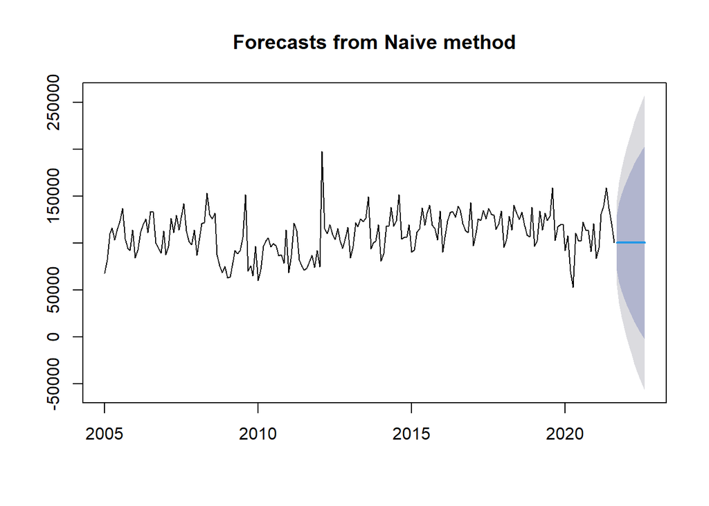

```r
honda_naive_f <- naive(honda_ts,h=12)
plot(honda_naive_f)
```

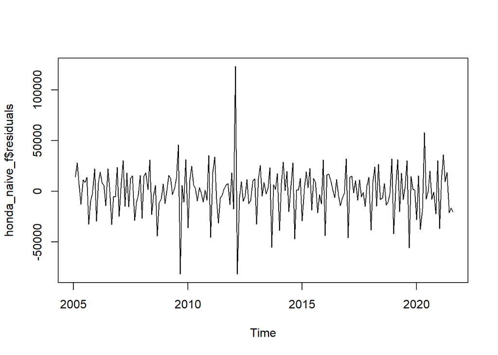

```r
plot(honda_naive_f$residuals)
```

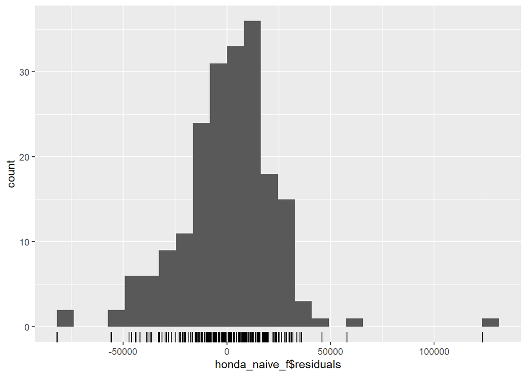

```r
gghistogram(honda_naive_f$residuals)
```

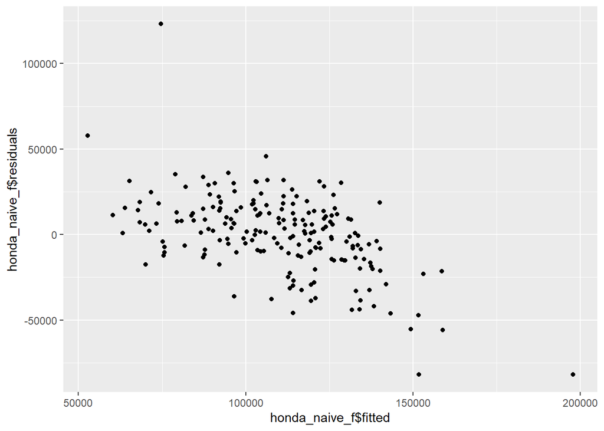

```r
ggplot(honda_ts,aes(x=honda_naive_f$fitted,y=honda_naive_f$residuals))+geom_point()
```

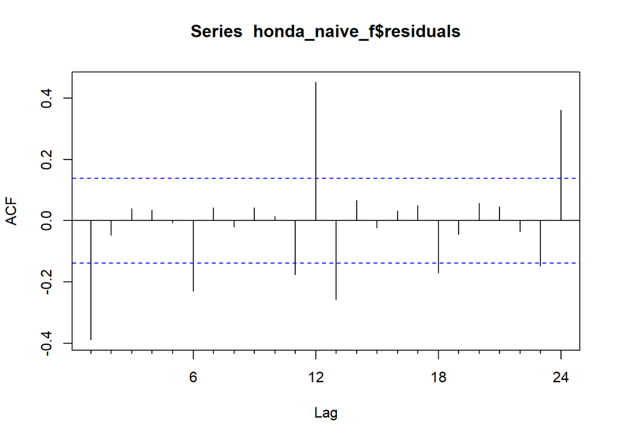

```r
Acf(honda_naive_f$residuals)
```

```r
acc_naive <- accuracy(honda_naive_f)
acc_naive
```

```
##                    ME     RMSE      MAE      MPE     MAPE     MASE       ACF1
## Training set 163.4372 23206.82 16954.84 -2.08726 16.14506 1.186157 -0.3888812
```

We can see that with the naive forecast the data is slightly skewed. The MAPE for Naive is 16 percent. We can use the Naive as a baseline model to see if other models perform better or worse than the naive.

## Random Walk

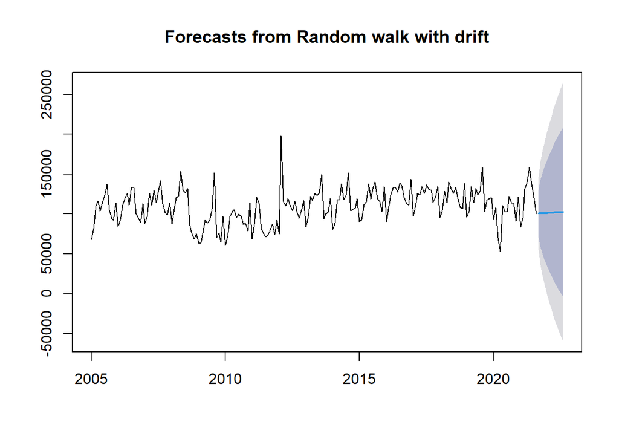

```r
honda_rwf_f <- rwf(honda_ts,12,drift = TRUE)
plot(honda_rwf_f)
```

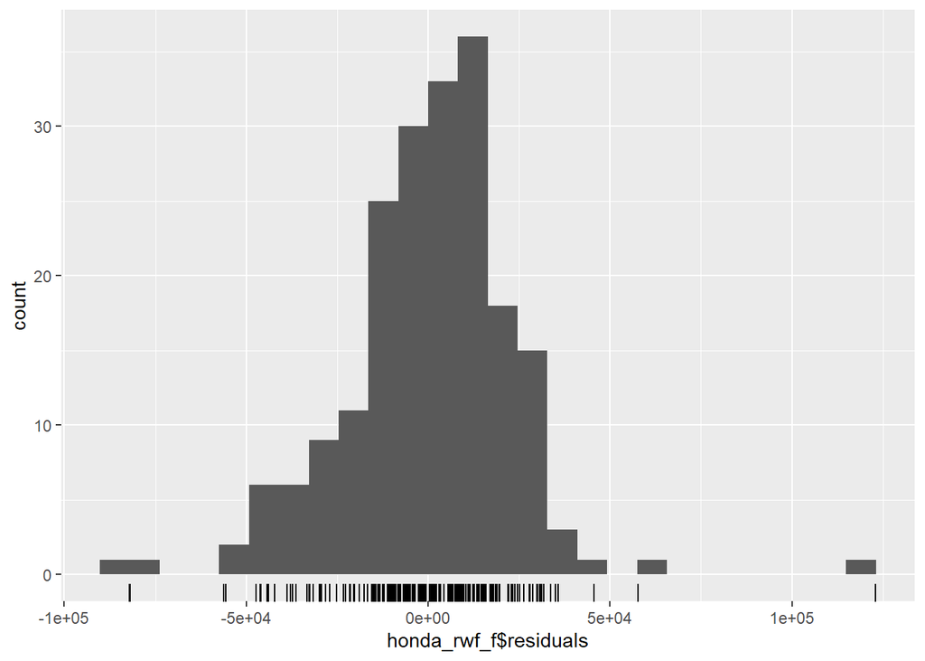

```r
gghistogram(honda_rwf_f$residuals)
```

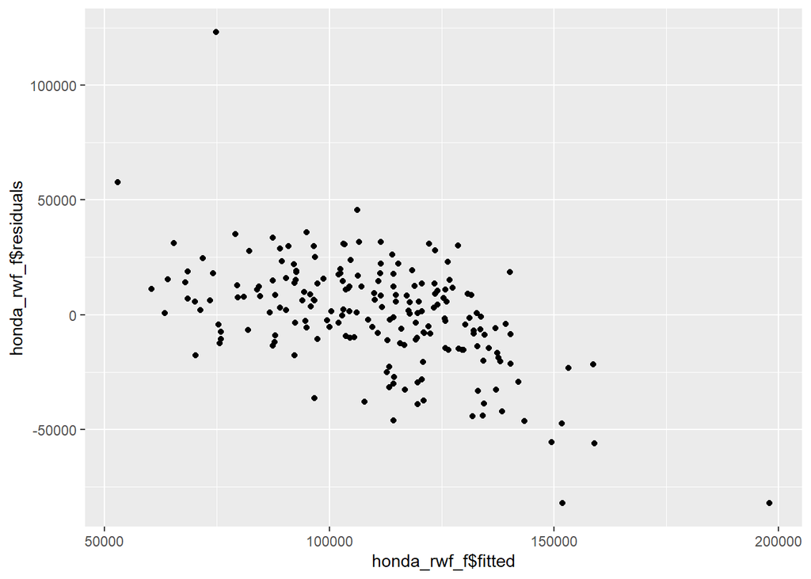

```r
ggplot(honda_ts,aes(x=honda_rwf_f$fitted,y=honda_rwf_f$residuals))+geom_point()
```

```r
acc_rwf <- accuracy(honda_rwf_f)
acc_rwf
```

```
##                         ME     RMSE      MAE       MPE     MAPE     MASE
## Training set -3.363277e-12 23206.24 16940.88 -2.242958 16.14329 1.185181
##                    ACF1
## Training set -0.3888812
```

With random walk forecast, the forecast is similar to what we saw in the Naive method. The data is slightly skewed and the MAPE measure is 16 percent. Although the difference we can see is in the point forecasts. The naive method gave a standard point forecast as output for the whole 12 month period while in random walk we can see that the point forecast slightly increases on a month-to-month basis.

## Snaive Forecast

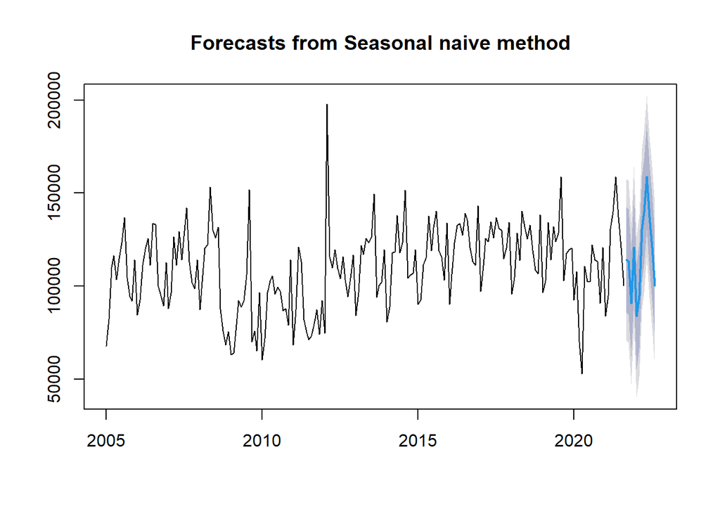

```r
honda_snaive_f <- snaive(honda_ts,12)
plot(honda_snaive_f)
```

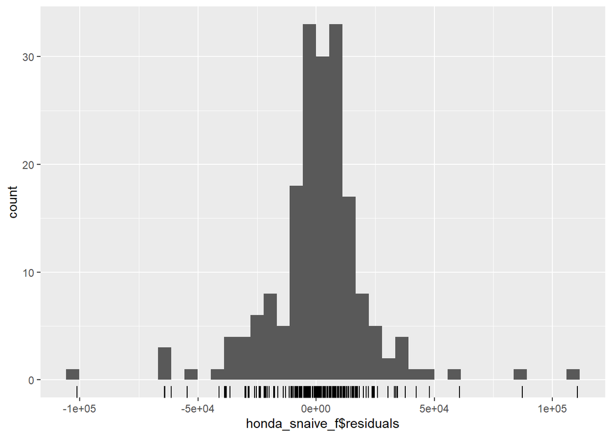

```r
gghistogram(honda_snaive_f$residuals)
```

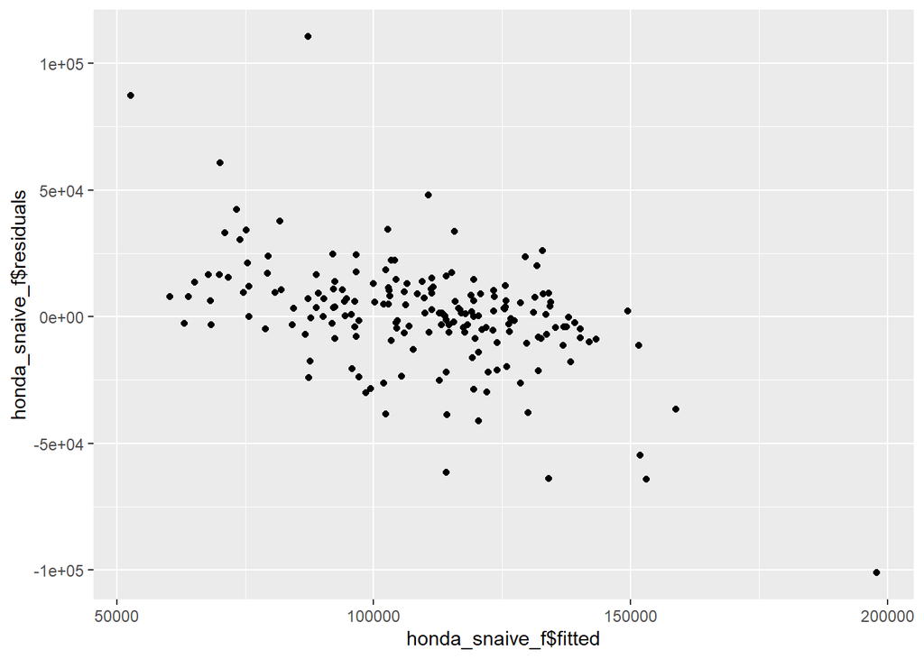

```r
ggplot(honda_ts,aes(x=honda_snaive_f$fitted,y=honda_snaive_f$residuals))+geom_point()
```

```r
acc_snaive <- accuracy(honda_snaive_f)
acc_snaive
```

```
##                    ME     RMSE      MAE       MPE     MAPE MASE    ACF1
## Training set 772.2021 22144.04 14293.93 -1.553783 14.03966    1 0.41209
```

With the Snaive we can see that the forecast shows an up/down trend as the seasonality factor which is an important factor in this sales data comes into consideration. The histogram is around the 0 scale denoting it relatively normal than the naive and random walk. The MAPE value is also lower than the naive method at 14 percent, indicating snaive to be a better model for forecasting.

## Simple Moving Average:

```r
honda_sma_f3  <- ma(honda_ts,order = 3)
honda_sma_f6  <- ma(honda_ts,order = 6)
honda_sma_f12 <- ma(honda_ts,order = 12)
```

Plotting the time-line:

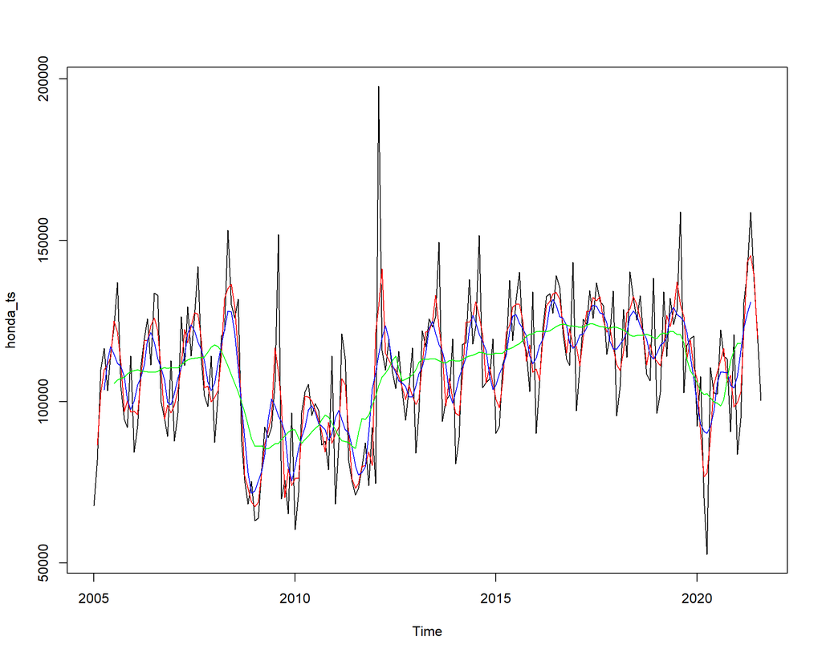

```r
plot(honda_ts)
lines(honda_sma_f3,col="red")
lines(honda_sma_f6,col="blue")
lines(honda_sma_f12,col="green")
```

```r
honda_sma_forecast1 <- forecast(honda_sma_f12,h=12)
honda_sma_forecast2 <- forecast(honda_sma_f3,h=12)
honda_sma_forecast3 <- forecast(honda_sma_f6,h=12)
```

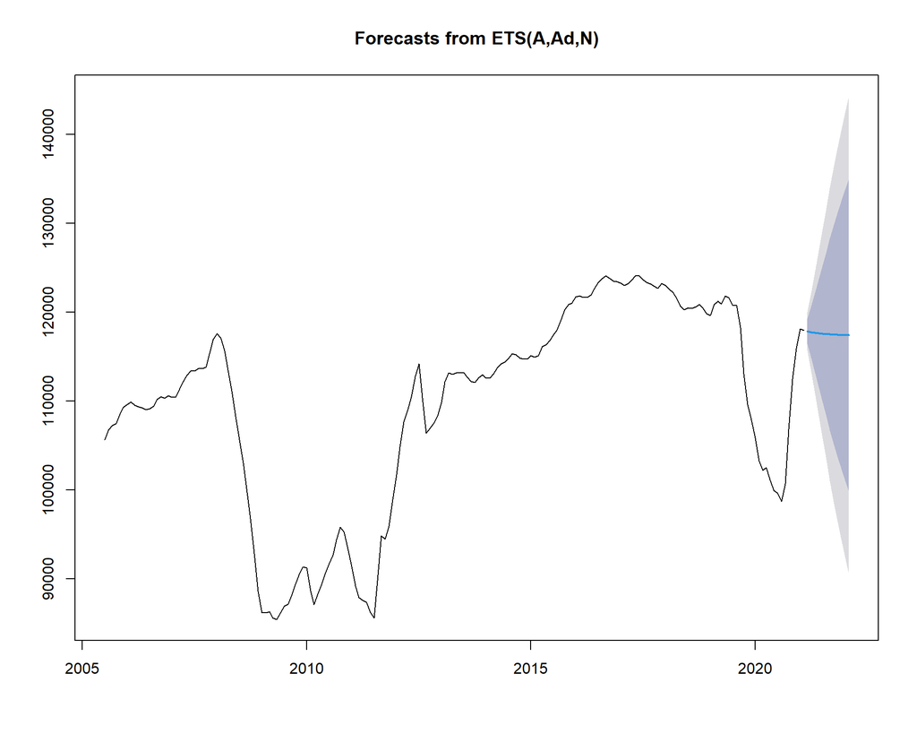

```r
plot(honda_sma_forecast1)
```

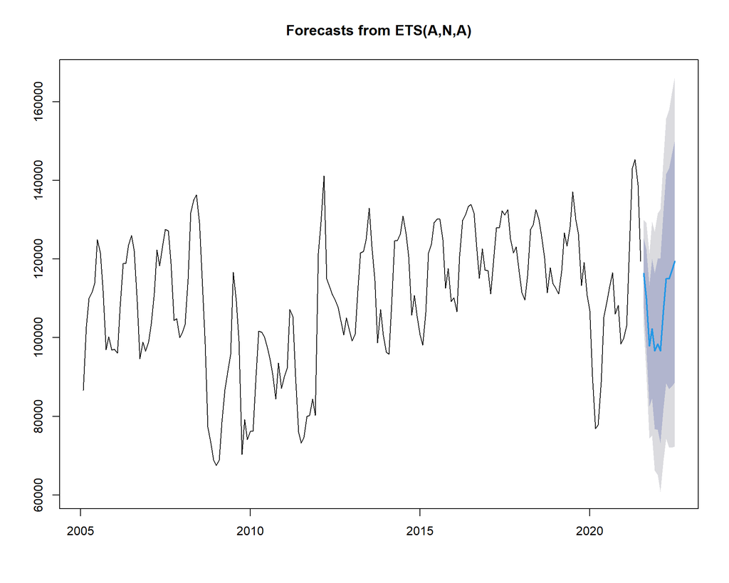

```r
plot(honda_sma_forecast2)
```

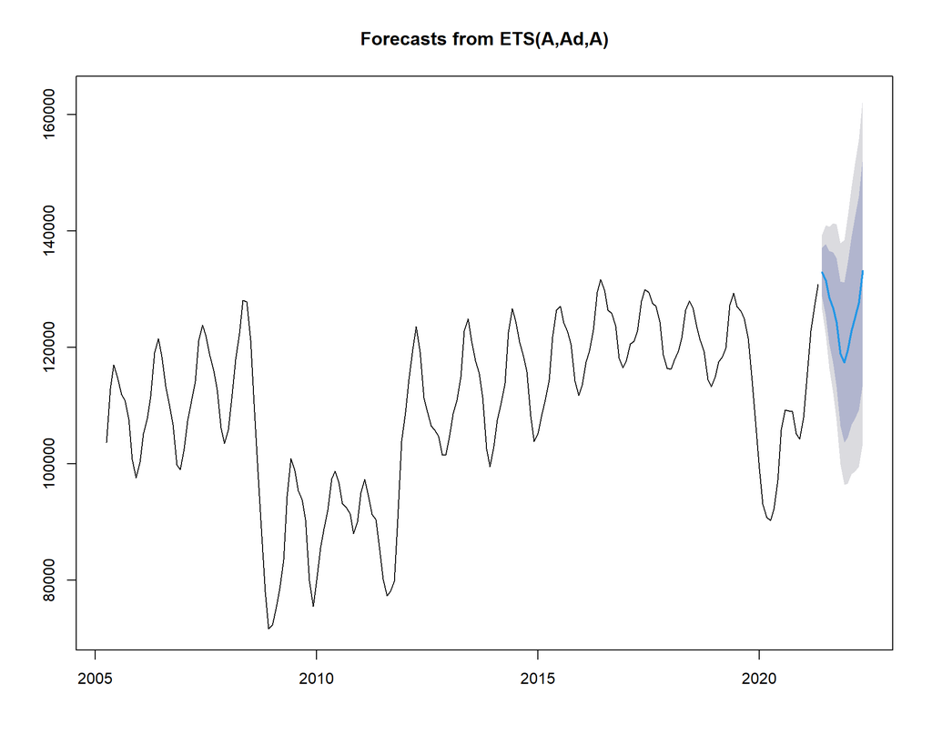

```r
plot(honda_sma_forecast3)
```

```r
honda_sma_forecast3
```

```
##          Point Forecast    Lo 80    Hi 80     Lo 95    Hi 95
## Jun 2021       132916.8 128731.9 137101.6 126516.62 139316.9
## Jul 2021       131510.1 125297.0 137723.3 122008.02 141012.3
## Aug 2021       128603.6 120647.1 136560.1 116435.14 140772.0
## Sep 2021       126776.5 117231.3 136321.6 112178.44 141374.5
## Oct 2021       124317.1 113293.1 135341.2 107457.36 141176.9
## Nov 2021       118921.7 106506.9 131336.5  99934.85 137908.6
## Dec 2021       117426.6 103696.1 131157.2  96427.57 138425.7
## Jan 2022       119502.8 104522.6 134482.9  96592.58 142412.9
## Feb 2022       122951.6 106781.0 139122.2  98220.85 147682.4
## Mar 2022       125101.4 107793.8 142408.9  98631.78 151571.0
## Apr 2022       127633.6 109237.8 146029.5  99499.57 155767.7
## May 2022       133212.6 113772.7 152652.4 103481.88 162943.2
```

For the simple moving averages, a forecast derived from a 12-period moving average will exhibit a pattern similar to that of a decomposition trend line. No seasonality will be displayed. Since Honda sales volumes have historically displayed a high level of seasonality, we do not believe a 12-period moving average model would be appropriate.

The 3-period and 6-period moving averages would offer better forecasting models as they do exhibit seasonal trends on a month-to-month basis.

#### Accuracy for Simple moving average:

```r
acc_sma1 <- accuracy(honda_sma_forecast1)
acc_sma2 <- accuracy(honda_sma_forecast2)
acc_sma3 <- accuracy(honda_sma_forecast3)
acc_sma2
```

```
##                     ME     RMSE      MAE        MPE     MAPE     MASE      ACF1
## Training set -0.481877 6684.548 4164.735 -0.2039638 4.016632 0.368766 0.2955057
```

```r
acc_sma3
```

```
##                    ME     RMSE     MAE        MPE     MAPE      MASE      ACF1
## Training set 51.61771 3119.085 1948.45 0.03817252 1.903143 0.2194495 0.6209045
```

We can see that for a degree 3, the MAPE measure is 4 percent while for degree 6 the MAPE measure is 1.9 percent, which indicate that the 3-period and 6-period model forecasts are 96 percent and 98 percent accurate, respectively. While these metrics are encouraging, we do have to recognize that our data set includes roughly 16 years - or two economic cycles, each of which include major outliers. We believe by subsetting the data and concentrating on one economic cycle (2012-2021), we can achieve an even more reliable forecast. We discuss more below.

## ETS method

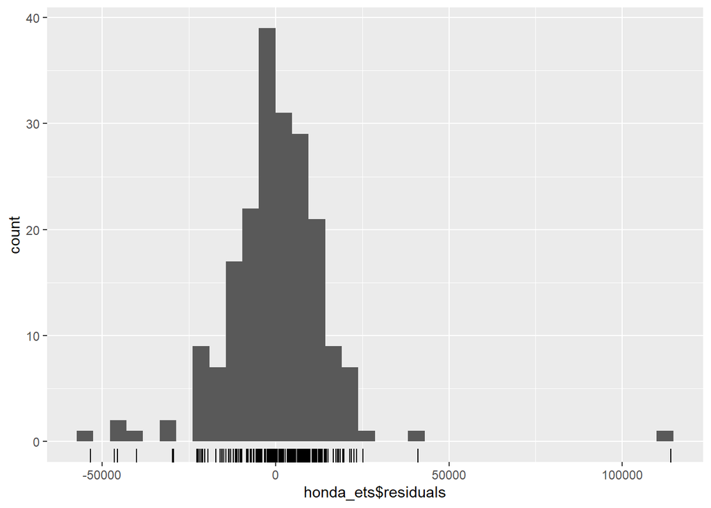

```r
honda_ets <- ets(honda_ts)
gghistogram(honda_ets$residuals)
```

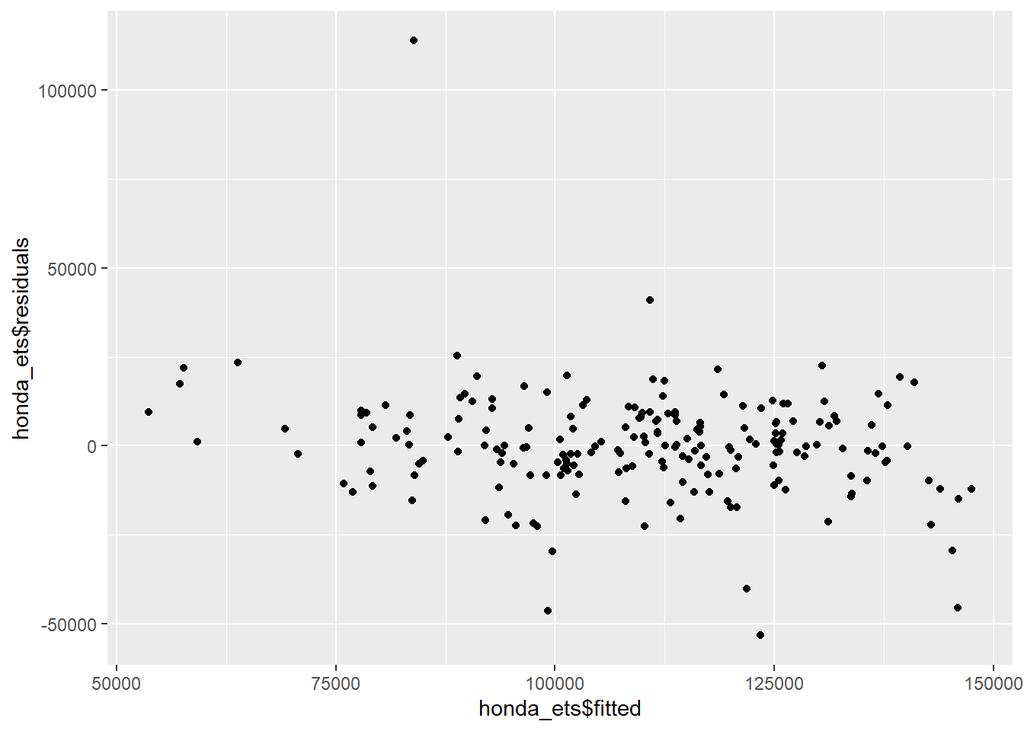

```r
ggplot(honda_ts,aes(x=honda_ets$fitted,y=honda_ets$residuals))+geom_point()
```

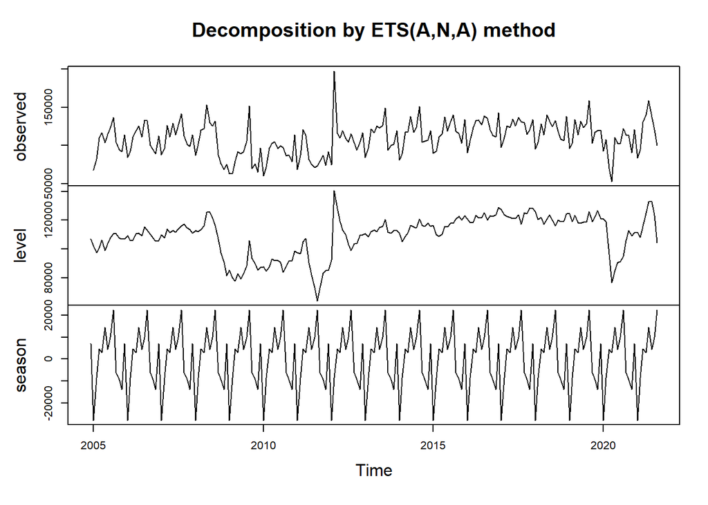

```r
plot(honda_ets)
```

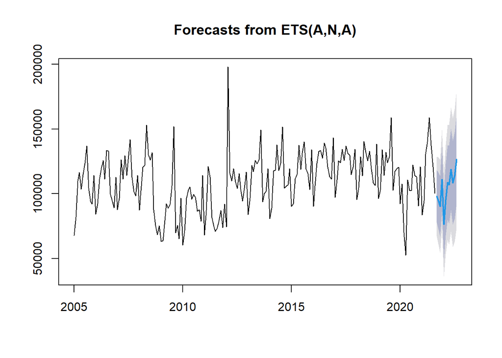

```r
honda_ets_forecast <- forecast(honda_ets,h=12)
plot(honda_ets_forecast)
```

```r
acc_ets <- accuracy(honda_ets)
acc_ets
```

```
##                     ME     RMSE      MAE       MPE     MAPE     MASE       ACF1
## Training set -32.77218 15077.14 9794.012 -1.510896 9.566092 0.685187 0.09798934
```

In the ETS method as well, we can see that the histogram is skewed. While the forecast appears reasonable, the MAPE measure of 9.5 percent is far too high to be a reliable model. There is not enough improvement relative to our Naive model to proceed with the ETS approach.

## Holts-Winter

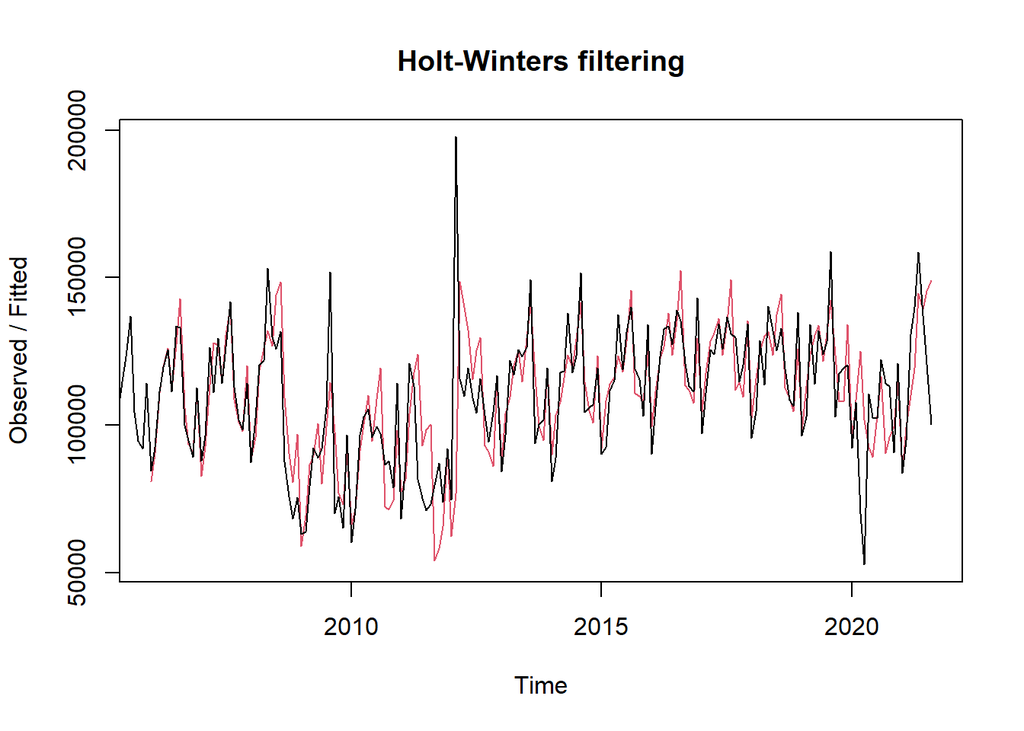

```r
honda_hw_f <- HoltWinters(honda_ts)
plot(honda_hw_f)
```

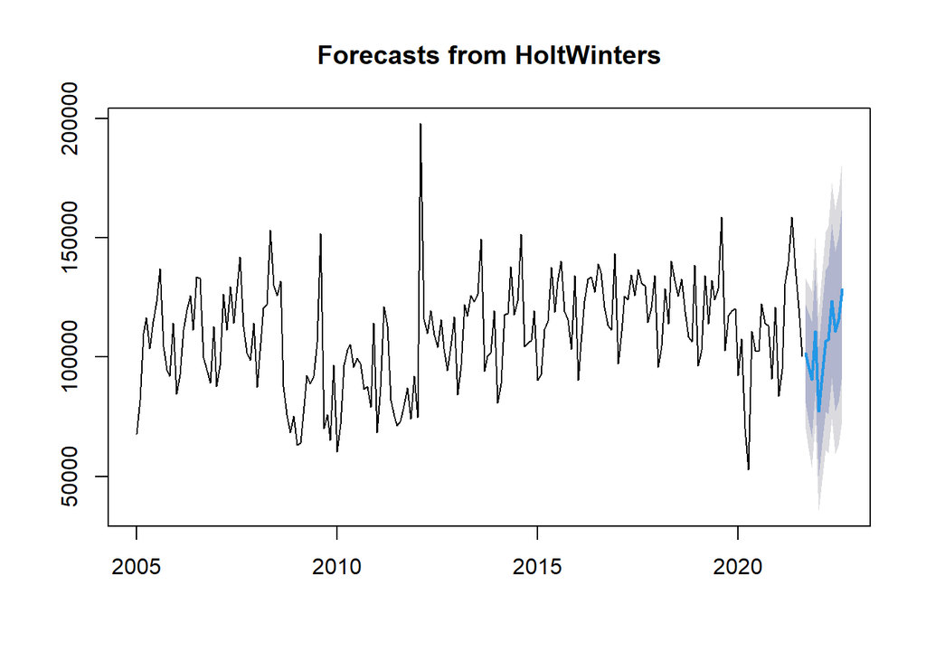

```r
honda_hw_forecast <- forecast(honda_hw_f,h=12)
plot(honda_hw_forecast)
```

```r
acc_hw <- accuracy(honda_hw_forecast)
acc_hw
```

```
##                     ME     RMSE     MAE       MPE     MAPE      MASE       ACF1
## Training set -757.8264 16120.32 10147.3 -2.100123 9.876625 0.7099026 0.08730733
```

With the HoltWinters method, we can see that the point forecast is similar to the ETS model, but the MAPE measure is 9.9 percent, a bit worse than the ETS model as well.

# Subsetting the data:

Following the spike observed in 2012, a more normal economic cycle emerges for the period between 2012-2021, making for a better time frame for forecasting purposes. With that in mind, we subset the data to assess whether or not the forecasts and accuracy measures will improve.

```r
honda1 <- read_excel("Honda Sales Data - Copy.xlsx")
```

## Converting into a Time-Series

```r
honda_subts <- ts(honda1$Car_Sales,frequency = 12,start = c(2012,1),end = c(2021,8))
honda_subts
```

```
##         Jan    Feb    Mar    Apr    May    Jun    Jul    Aug    Sep    Oct
## 2012  74628 197798 115833 109837 119411 109438 104119 115675 103475  94270
## 2013  84137  96623 121938 117100 125649 123150 126289 149378  93915 100242
## 2014  80808  88860 117738 118333 137928 117817 123428 151551 104391 105906
## 2015  90202  92474 111623 115194 137551 118870 131409 140178 119046 115572
## 2016  90247 106213 123369 132623 133547 127363 139125 135325 120842 113292
## 2017  97178 110822 125531 123984 134475 125755 136803 131076 129776 114655
## 2018  95634 104588 128585 113813 140250 132031 125355 132834 119157 108558
## 2019  96375 102926 134101 114088 131985 123953 128537 158804 102827 117486
## 2020  92395 107742  70116  52705 110636 102703 102374 122278 114117 113197
## 2021  83721  94775 130707 140023 158662 137238 120692 100364
##         Nov    Dec
## 2012 104334 116740
## 2013 101948 119504
## 2014 106957 119472
## 2015 103197 134070
## 2016 111308 143239
## 2017 120440 134255
## 2018 106481 138341
## 2019 119470 120433
## 2020  90723 120819
## 2021
```

```r
attributes(honda_subts)
```

```
## $tsp
## [1] 2012.000 2021.583   12.000
##
## $class
## [1] "ts"
```

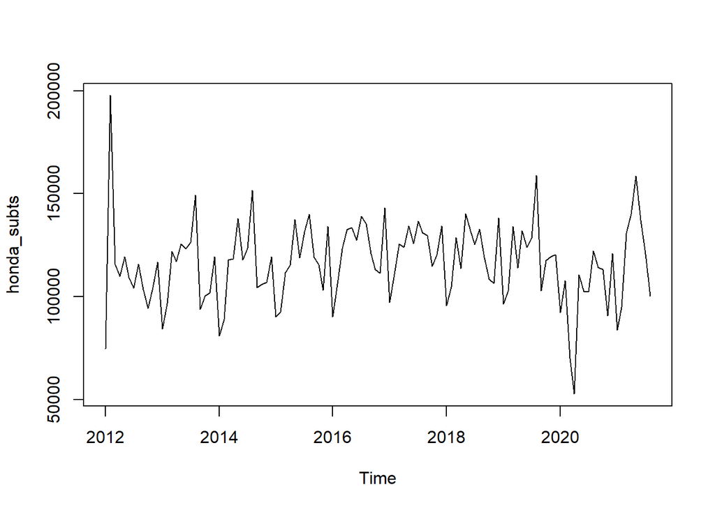

```r
plot(honda_subts)
```

#### Central Tendency

```r
summary(honda_subts)
```

```
##    Min. 1st Qu.  Median    Mean 3rd Qu.    Max.
##   52705  104280  117778  116654  128883  197798
```

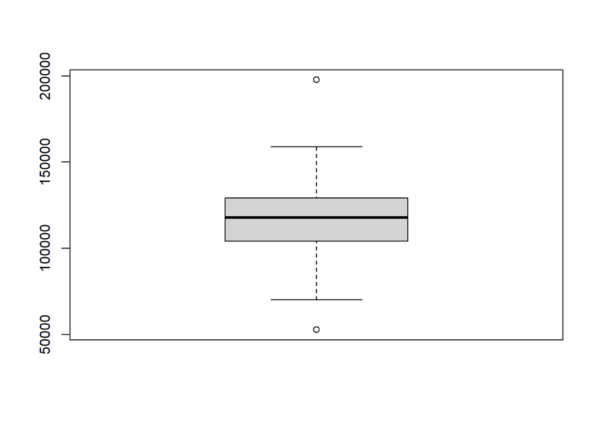

```r
boxplot(honda_subts)
```

We can see from the summary that the mean sales increased to 116,654 from the 109,536 mean for the whole data.